# Lab 2: Gene Expression in Human Airway Cells

Khushboo Singh

2026-09-16

## Research question

Which genes have the largest differences in average expression between dexamethasone-treated and untreated human airway smooth-muscle cells?

## Data source

The processed FPKM gene-expression matrix will be downloaded directly from NCBI GEO study GSE52778.

## Analysis plan

Calculate average expression across four treated and four untreated samples. Calculate log2 fold changes using a pseudocount of 0.1, keep records with average expression of at least 1 FPKM in either group, and plot the ten largest absolute log2 fold changes. This is a descriptive comparison, not a statistical significance test.

## Load the data

```r
url <- paste0(
  "https://www.ncbi.nlm.nih.gov/geo/download/",
  "?acc=GSE52778&format=file&file=GSE52778_All_Sample_FPKM_Matrix.txt.gz"
)

raw_file <- tempfile(fileext = ".gz")
download.file(url, raw_file, mode = "wb")

fpkm <- read.table(
  gzfile(raw_file),
  header = TRUE,
  sep = "",
  stringsAsFactors = FALSE,
  check.names = FALSE,
  quote = "",
  comment.char = ""
)

dim(fpkm)
```

```
## [1] 23273    41
```

```r
head(fpkm, 3)
```

```
##       gene_id tracking_id class_code nearest_ref_id gene_short_name   tss_id
## 1 1/2-SBSRNA4 1/2-SBSRNA4          -              -     1/2-SBSRNA4 TSS17399
## 2        A1BG        A1BG          -              -            A1BG TSS11073
## 3    A1BG-AS1    A1BG-AS1          -              -        A1BG-AS1 TSS13066
##                      locus length coverage Dex_FPKM Dex_conf_lo Dex_conf_hi
## 1 chr4:110351118-110461615      -        - 0.483373     0.00000     2.67442
## 2  chr19:58858171-58874214      -        - 4.391180     1.55759     7.22477
## 3  chr19:58858171-58874214      -        - 1.226080     0.00000     2.52180
##   Dex_status Alb_FPKM Alb_conf_lo Alb_conf_hi Alb_status Untreated_FPKM
## 1         OK 0.494055    0.000000     3.09769         OK       0.525991
## 2         OK 3.841650    0.905369     6.77793         OK       3.482220
## 3         OK 0.981673    0.000000     2.26610         OK       0.765875
##   Untreated_conf_lo Untreated_conf_hi Untreated_status Alb_Dex_FPKM
## 1           0.00000           2.20219               OK     0.339559
## 2           1.45165           5.51280               OK     4.438090
```

[output cut: 17 more lines]

## Calculate group averages

```r
dex_columns <- c("Dex_LL14", "Dex_LL06", "Dex_LL02", "Dex_LL10")

untreated_columns <- c(
  "Untreated_LL09",
  "Untreated_LL05",
  "Untreated_LL13",
  "Untreated_LL01"
)

analysis <- fpkm

analysis$mean_dex <- rowMeans(analysis[, dex_columns])
analysis$mean_untreated <- rowMeans(analysis[, untreated_columns])

head(analysis[, c("gene_short_name", "mean_dex", "mean_untreated")], 5)
```

```
##   gene_short_name    mean_dex mean_untreated
## 1     1/2-SBSRNA4 0.471302250     0.51705225
## 2            A1BG 4.092237500     3.32544250
## 3        A1BG-AS1 1.244651750     0.76529950
## 4            A1CF 0.002698945     0.00462829
## 5           A2LD1 2.064377500     1.97019500
```

## Compare treated and untreated expression

```r
analysis$log2_fold_change <- log2(
  (analysis$mean_dex + 0.1) /
  (analysis$mean_untreated + 0.1)
)

head(
  analysis[, c(
    "gene_short_name",
    "mean_dex",
    "mean_untreated",
    "log2_fold_change"
  )],
  5
)
```

```
##   gene_short_name    mean_dex mean_untreated log2_fold_change
## 1     1/2-SBSRNA4 0.471302250     0.51705225      -0.11113845
## 2            A1BG 4.092237500     3.32544250       0.29143008
## 3        A1BG-AS1 1.244651750     0.76529950       0.63596110
## 4            A1CF 0.002698945     0.00462829      -0.02685163
## 5           A2LD1 2.064377500     1.97019500       0.06418548
```

## Select the largest expression changes

```r
expressed_genes <- analysis[
  (analysis$mean_dex >= 1) |
  (analysis$mean_untreated >= 1),
]

expressed_genes$absolute_change <- abs(
  expressed_genes$log2_fold_change
)

ranked_genes <- expressed_genes[
  order(expressed_genes$absolute_change, decreasing = TRUE),
]

top_genes <- head(ranked_genes, 10)

top_genes[, c(
  "gene_short_name",
  "mean_dex",
  "mean_untreated",
  "log2_fold_change"
)]
```

```
##       gene_short_name mean_dex mean_untreated log2_fold_change
## 19398         SNORD54    0.000   1.792328e+04        -17.45148
## 6778              FTL 9799.498   0.000000e+00         16.58043
## 16897           QSOX1    0.000   3.157470e+03        -14.94653
## 3910           COL1A2 1608.342   0.000000e+00         13.97338
## 19362         SNORD29 8959.450   4.584785e-01         13.96964
## 12561         MIR374C 1397.815   0.000000e+00         13.77099
## 13164          MIR611    0.000   1.163287e+03        -13.50604
## 19455         SNORD98    0.000   1.163287e+03        -13.50604
## 12803        MIR4524A    0.000   1.063702e+03        -13.37694
## 12334         MIR24-1 5387.020   4.245397e-01         13.32617
```

## Visualize the largest changes

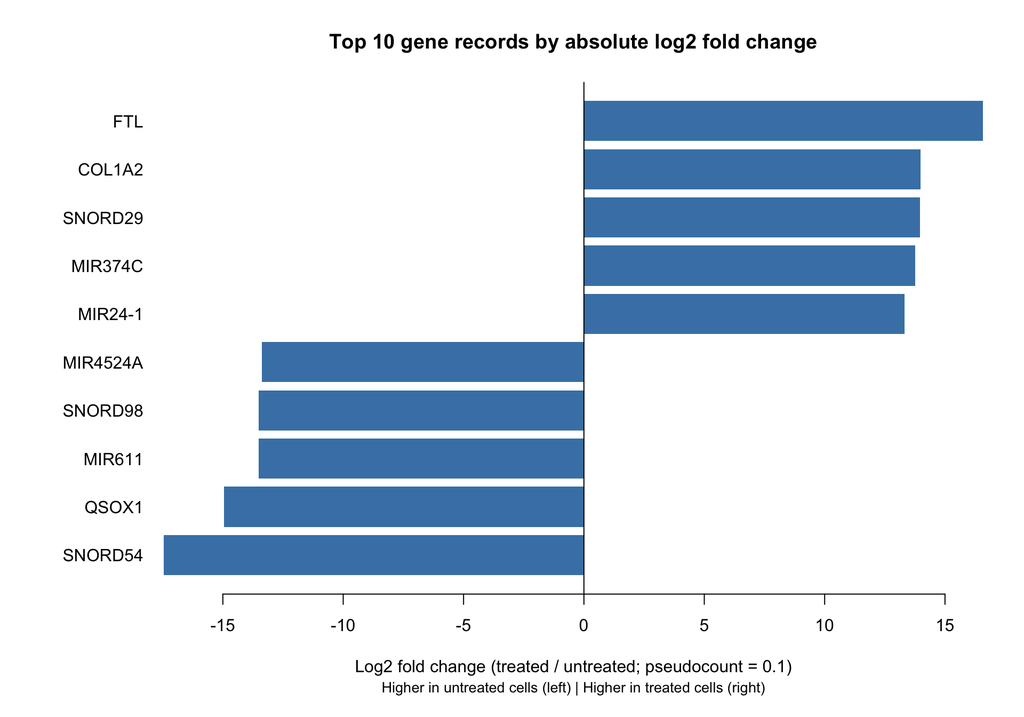

```r
plot_data <- top_genes[
  order(top_genes$log2_fold_change),
]

par(mar = c(6, 8, 4, 2))

barplot(
  plot_data$log2_fold_change,
  names.arg = plot_data$gene_short_name,
  horiz = TRUE,
  las = 1,
  col = "steelblue",
  border = NA,
  main = "Top 10 gene records by absolute log2 fold change",
  xlab = "Log2 fold change (treated / untreated; pseudocount = 0.1)"
)

abline(v = 0, col = "black")

mtext(
  "Higher in untreated cells (left) | Higher in treated cells (right)",
  side = 1,
  line = 4,
  cex = 0.85
)
```

## Interpretation

I observed higher average expression of FTL in treated cells. I observed lower average expression of SNORD54 in treated cells. When one group’s average was zero, the calculated fold change was sensitive to the pseudocount of 0.1. This analysis compared average expression but did not test statistical significance.

## Python–R comparison

There were matching group mean values, the top ten values, and the log2 fold changes between Python and R. The outputs seem equally reliable since the methods used were identical; however, none of the analyses checked for significance, and zero values made some of the fold changes susceptible to the pseudocount value. Python was faster for me to write because I am more familiar with its syntax, which made selecting columns and calculating group averages easier for me.

## AI Assistance

I used OpenAI ChatGPT to help write and explain the R code for downloading and loading the dataset, calculating group averages and log2 fold changes, filtering and ranking gene records. I ran the R code and compared the displayed results with Python. Further details of AI assistance are documented in AI_USAGE.md.